# ORF_metaplot

Roberto Albanese

17/02/2023

# Metaplots of Ribo-seq and RNA-seq profiles around stop codons of the most translated ORFs

## Setting the computational environment

First, I attach the needed R packages. Then, I set the environment by loading the annotation object, *ORFquant* results of time point 14h, and the Ribo-seq and RNA-seq profile files.

After loading *ORFquant* results I get an object (*ORFquant_results_filt*) with transcript coordinates of ORFs which do not belong to categories ‘uORF’ and ‘overl_uORF’.

```r
# ---- Attaching the needed R packages ----
suppressMessages(library("rtracklayer"))
suppressMessages(library("GenomicFeatures"))
suppressMessages(library("GenomicRanges"))
suppressMessages(library("GenomicAlignments"))
suppressMessages(library("ggplot2"))
suppressMessages(library("dplyr"))
suppressMessages(library("ORFquant"))
suppressMessages(library("readxl"))
suppressMessages(library("viridis"))

# Getting the GENCODE v25 annotation information
load_annotation("/group/calviello/Lorenzo/Annotation/human/RiboseQC/gencode.v25.annotation.gtf.gz_Rannot")
# Getting ORFquant results, filtering them, and setting values for "NMD_candidate_compatible_txs"
ORFquant_results <- get(load("/group/calviello/Lorenzo/Backup_SF/bckps/suja/ORFquant/DUX4_ORFquant_final_ORFquant_results"))
ORFquant_results_filt <- ORFquant_results$ORFs_tx
ORFquant_results_filt <- ORFquant_results_filt[!ORFquant_results_filt$ORF_category_Tx_compatible%in%c("uORF","overl_uORF")]
ORFquant_results_filt$NMD_candidate_compatible_txs <- sum(ORFquant_results_filt$NMD_candidate_compatible_txs) > 0
# Getting the paths of the Ribo P_sites_uniq bedgraph files
ribo_profile_files <- list.files(path="/group/calviello/Roberto/RiboseQC_on_each_sample", pattern="Ribo.*P_sites_uniq.*bedgraph", recursive=T, full.names=T)
# Getting the paths of the RNA coverage_uniq files
rna_profile_files <- list.files(path="/group/calviello/Roberto/RiboseQC_on_each_sample", pattern="RNA.*coverage_uniq", recursive=T, full.names=T)
```

## Functions

In the following section I define two functions.

The first function, i.e., *getExtendedEndCoords*, allows to get genomic regions surrounding end coordinates of ORFs. A *GRanges* object with genomic coordinates of the most translated NMD/no-NMD ORFs is specified as value of the parameter ‘most_transl_ORFs’. After obtaining genomic coordinates of ORF end coordinates (single nucleotide positions), they are extended on both sides by the value of the parameter ‘desired_size’ (50 by default).

The second function, i.e., *getNormalizedVector*, allows to get the vector of normalized values of a specific time point. A character vector with paths to profile files (*rna_profile_files* or *ribo_profile_files*) is specified as value of the parameter ‘profile_files’. Moreover, a numeric vector with positions of the first profile files of the different samples is specified as value of the parameter ‘sample_indices’.

```r
# 1) Function to get extended coordinates of the most translated ORFs

# Default:
# - Genomic coords of the most translated ORFs on no-NMD targets as value of the 'most_transl_ORFs' parameter
# - 50 as value for the 'desired_size' parameter

getExtendedEndCoords <- function(most_transl_ORFs=mosttr_nonmd_coords, desired_size=50) {

  # Storing coords of the most translated ORFs into a different variable and obtaining the strand of each ORF
  ext_most_transl_ORFs <- most_transl_ORFs
  str_nmd <- sapply(ext_most_transl_ORFs, function(x) (return(unique(strand(x)))))

  # Getting coordinates on plus strand and on minus strand
  ext_most_transl_ORFs_plus <- unlist(as(sapply(ext_most_transl_ORFs[str_nmd == "+"], function(x)(return(x[length(x)]))), "GRangesList"))
  ext_most_transl_ORFs_minus <- unlist(as(sapply(ext_most_transl_ORFs[str_nmd == "-"], function(x)(return(x[1]))), "GRangesList"))

  # Creating a GRanges object with coordinates of both strands
  ext_most_transl_ORFs <- c(ext_most_transl_ORFs_plus,
                            ext_most_transl_ORFs_minus)

  # Getting coordinates as coordinates of single nucleotides
  ext_most_transl_ORFs <- resize(ext_most_transl_ORFs, width=1, fix="end")

  # Extending the coordinates by the desired size with the command 'flank'
  ext_most_transl_ORFs <- flank(ext_most_transl_ORFs, width=desired_size, both=TRUE)

  # Adding two metadata columns with ORF IDs and gene names
  mcols(ext_most_transl_ORFs)$id <- names(ext_most_transl_ORFs)
  mcols(ext_most_transl_ORFs)$gene_name <- ORFquant_results$ORFs_tx$gene_name[match(ext_most_transl_ORFs$id, ORFquant_results$ORFs_tx$ORF_id_tr)]

  # Sorting by gene name with the command 'order'
  ext_most_transl_ORFs <- ext_most_transl_ORFs[order(ext_most_transl_ORFs$gene_name)]

  return(ext_most_transl_ORFs)
}

# 2) Function to get the vector with normalized values of a time point

# Default:
# - c(1,3,5) as value of the parameter 'sample_indices'
# - rna_profile_files as value of the parameter 'profile_files'
# - "RNA" as value of the parameter 'assay'

getNormalizedVector<- function(sample_indices=c(1,3,5), profile_files=rna_profile_files, assay="RNA") {

  # Initializing an empty list with 3 elements
  matrices_list <- vector(mode="list", length=3)

  # Initializing a counter
  j = 1
  for (i in sample_indices) {

    # Importing the profiles (both strands)
    profiles_minus <- import(profile_files[i])
    strand(profiles_minus) <- "-"
    profiles_plus <- import(profile_files[i+1])
    strand(profiles_plus) <- "+"
    profiles <- c(profiles_minus, profiles_plus)

    if (assay=="Ribo"){
      correction<-sum(profiles$score*width(profiles))/1e06
      profiles$score <- profiles$score/correction
    }

    # Adding seqinfo from annotation
    seqinfo(profiles)<-GTF_annotation$seqinfo

    # Obtaining coverage, filtering by using extended coords, and
    # obtaining the corresponding matrices
    cov_gen <- coverage(profiles, weight=profiles$score)
    # -- Replacing runValue of cov_gen with values that are rounded to 5 decimal places
    run_val <- round(runValue(cov_gen), digits=5)
    runValue(cov_gen) <- run_val
    # --
    cov_gen_nmd_mat <- as.matrix(cov_gen[extcoords_mosttr_nmd])
    cov_gen_nonmd_mat <- as.matrix(cov_gen[extcoords_mosttr_nonmd])

    # Binding the two matrices
    cov_gen_mat<- cbind(cov_gen_nmd_mat, cov_gen_nonmd_mat)

    # Inverting minus strand coverage (it was done automatically Lorenzo thought)
    strando<-as.vector(strand(extcoords_mosttr_nmd)=="-")
    cov_gen_mat[strando,]<-cov_gen_mat[strando,c(100:1,200:101)]

    # Setting the element of the list
    matrices_list[[j]] <- cov_gen_mat

    j = j + 1
  }

  # Computing means at the single gene level and general means
  matrices_list<-Reduce('+', matrices_list)/3
  time_point_vec<-colMeans(t(apply(matrices_list,1,function(x){x/sum(x)})),na.rm=T)
  # Normalizing values: dividing them by the maximum value
  max_val <- max(time_point_vec, na.rm=TRUE)
  time_point_vec <- time_point_vec/max_val
  # Replacing NaNs with 0
  time_point_vec[is.nan(time_point_vec)] <- 0

  # Returning the vector
  return(time_point_vec)
}
```

## Getting the genomic coordinates of the most translated ORFs

In the following section genomic coordinates of the most translated ORFs are obtained.

First, metadata columns of the object *ORFquant_results_filt* are stored inside a variable. Then, the variable is split by gene name, and a function is applied to each element: the function sorts ORFs by *ORF_pct_P_sites* values (in decreasing order); it then obtains the most translated no-NMD ORF and the most translated NMD ORF per each gene. After applying the function to all the elements, a list is obtained. Each element is related to a different gene, and it can contain either one ORF ID or two ORF IDs.

After filtering the list by selecting elements with two ORF IDs, the command *unlist* is used to get a vector (The length of the vector, which is the number of ORF IDs, is stored in a variable).

Genomic coordinates of ORFs, which are in the *ORFs_gen* object of *ORFquant_results*, are split by ORF ID. Genomic coordinates of the most translated no-NMD ORFs as well as genomic coordinates of the most translated NMD ORFs are obtained. At the end of this section, two *GRangesList* objects contain these two groups of coordinates. Each element of these *GRangesLists* contains the genomic coordinates of an ORF, which is divided into different parts/exons.

```r
# Getting the most translated ORFs (NMD and non NMD)
orfe<-mcols(ORFquant_results_filt)[,c("ORF_id_tr","ORF_pct_P_sites","gene_name","ORF_category_Tx_compatible","NMD_candidate_compatible_txs")]
mosttr<-lapply(split(orfe,orfe$gene_name),function(x){
  x<-x[order(x$ORF_pct_P_sites,decreasing = T),]
  reso<-c(x[!x$NMD_candidate_compatible_txs,"ORF_id_tr"][1],x[x$NMD_candidate_compatible_txs,"ORF_id_tr"][1])
  reso[!is.na(reso)]
})

# Obtaining IDs
mosttr_with_nonmd_nmd <- mosttr[sapply(mosttr, length)==2]
mosttr_with_nonmd_nmd <- unlist(mosttr_with_nonmd_nmd)
num <- length(mosttr_with_nonmd_nmd)
# Splitting ORFs_gen by ORF ID
ORFs_gen_split_by_ORFid <- split(ORFquant_results$ORFs_gen, names(ORFquant_results$ORFs_gen))
# No NMD
mosttr_nonmd <- mosttr_with_nonmd_nmd[seq(num) %% 2 == 1]
mosttr_nonmd_coords <- ORFs_gen_split_by_ORFid[names(ORFs_gen_split_by_ORFid) %in% mosttr_nonmd]
names(mosttr_nonmd_coords) <- NULL
# NMD
mosttr_nmd <- mosttr_with_nonmd_nmd[seq(num) %% 2 == 0]
mosttr_nmd_coords <- ORFs_gen_split_by_ORFid[names(ORFs_gen_split_by_ORFid) %in% mosttr_nmd]
names(mosttr_nmd_coords) <- NULL
```

## Getting the extended end coordinates of the most translated ORFs

In this section the function *getExtendedEndCoords* is used to get extended end coordinates of the most translated NMD and no-NMD ORFs. The default value, 50, is used as value of the parameter ‘desired_size’.

```r
# Getting the extended end coordinates of the most translated ORFs on no-NMD and NMD targets
extcoords_mosttr_nonmd <- getExtendedEndCoords(most_transl_ORFs=mosttr_nonmd_coords)
extcoords_mosttr_nmd <- getExtendedEndCoords(most_transl_ORFs=mosttr_nmd_coords)
# setequal(extcoords_mosttr_nmd$gene_name, extcoords_mosttr_nonmd$gene_name)
```

## Excluding genes with PTCs (i.e., regions around NMD end coordinates) overlapping CDSs of annotated transcripts

Extended end coordinates are then filtered. First, the NMD extended end coordinates overlapping with CDS of annotated transcripts are identified. Then, these NMD regions as well as the corresponding no-NMD regions are excluded.

```r
# (check how to re-do this)
okgins<-which(!extcoords_mosttr_nmd%over%GTF_annotation$cds_txs)
extcoords_mosttr_nonmd<-extcoords_mosttr_nonmd[okgins]
extcoords_mosttr_nmd<-extcoords_mosttr_nmd[okgins]

# Getting a single GRanges object with all the extended end coordinates
extcoords_mosttr <- c(extcoords_mosttr_nonmd,
                      extcoords_mosttr_nmd)
# Saving the GRanges object
save(extcoords_mosttr, file="/group/calviello/Roberto/Suja_plots/extcoords_mosttr.RData")
```

## Getting vectors with normalized values (a vector for each combination of assay and time point)

In this section the function *getNormalizedVector* is used to get vectors with normalized values of the different time points (first for Ribo-seq, then for RNA-seq).

```r
# Getting the positions of odd indices
odd_indices <- seq(length(ribo_profile_files)) %% 2 == 1
w <- which(odd_indices==TRUE)

# Ribo-seq
ribo_00h_vec <- getNormalizedVector(sample_indices=w[1:3], profile_files=ribo_profile_files, assay="Ribo")
ribo_04h_vec <- getNormalizedVector(sample_indices=w[4:6], profile_files=ribo_profile_files, assay="Ribo")
ribo_08h_vec <- getNormalizedVector(sample_indices=w[7:9], profile_files=ribo_profile_files, assay="Ribo")
ribo_14h_vec <- getNormalizedVector(sample_indices=w[10:12], profile_files=ribo_profile_files, assay="Ribo")

# RNA-seq
rna_00h_vec <- getNormalizedVector(sample_indices=w[1:3], profile_files=rna_profile_files)
rna_04h_vec <- getNormalizedVector(sample_indices=w[4:6], profile_files=rna_profile_files)
rna_08h_vec <- getNormalizedVector(sample_indices=w[7:9], profile_files=rna_profile_files)
rna_14h_vec <- getNormalizedVector(sample_indices=w[10:12], profile_files=rna_profile_files)
```

## Visualizing the results

Finally, a dataframe with all results is created. The dataframe contains 5 columns: *ribo_vals*: normalized Ribo-seq values of all time points; *rna_vals*: normalized RNA-seq values of all time points; *group_txs*: the group, “NMD” or “No NMD”, for each normalized value; *time_point*: the time point for each normalized value; *x_vals*: value on x axis for each normalized value.

A column *frame* is added to the dataframe. Three different values (“Frame 0”, “Frame 1”, and “Frame 2”) are specified for this column depending on x axis values.

The dataframe is then used in the command *ggplot* to visualize the results. A barplot is used to visualize Ribo-seq normalized values, whereas an area plot is used to visualize the RNA-seq normalized values.

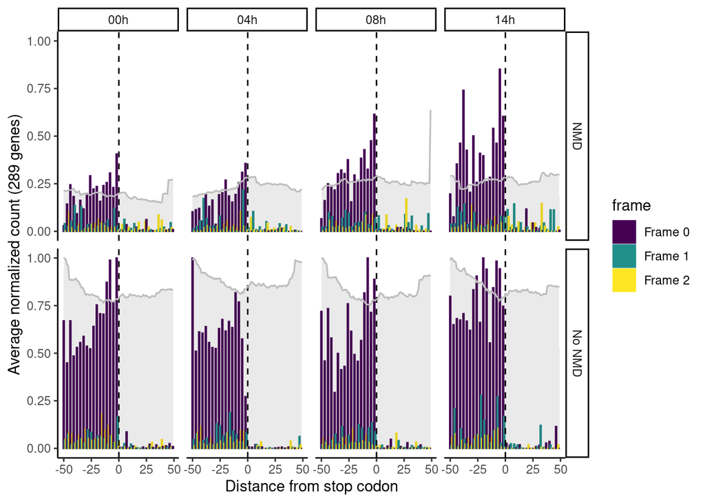

```r
# Creating total dataframe for the plot
total_plot_df <- data.frame(ribo_vals=c(ribo_00h_vec, ribo_04h_vec, ribo_08h_vec, ribo_14h_vec),
                            rna_vals=c(rna_00h_vec, rna_04h_vec, rna_08h_vec, rna_14h_vec),
                            group_txs=rep(c(rep("NMD", 100), rep("No NMD", 100)), 4),
                            time_point= rep(c("00h", "04h", "08h", "14h"), each=200),
                            x_vals=rep(-50:49, 8))
# Adding column with the used frame
total_plot_df$frame <- "Nothing"
total_plot_df[total_plot_df$x_vals%in%seq(from=-50, to=49, by=3),]$frame<-"Frame 0"
total_plot_df[total_plot_df$x_vals%in%seq(from=-49, to=49, by=3),]$frame<-"Frame 1"
total_plot_df[total_plot_df$x_vals%in%seq(from=-48, to=49, by=3),]$frame<-"Frame 2"

# Saving the data as an RData object
save(total_plot_df, file="df_notover_CDSs.RData")

# Plotting the results
ggplot(total_plot_df) +
  geom_bar(stat="identity", aes(x=x_vals, y=ribo_vals, color=frame, fill=frame)) +
  scale_color_viridis(discrete = TRUE, option="D") +
  scale_fill_viridis(discrete = TRUE, option="D") +
  geom_line(aes(x=x_vals, y=rna_vals), color="dark grey", alpha=0.7, group=1)+
  facet_grid(group_txs~time_point,scales = "fixed") +
  labs(x="Distance from stop codon",
       y=paste("Average normalized count (", length(extcoords_mosttr_nmd), " genes)",sep = "")) +
  theme_classic() + geom_vline(xintercept = 0,lty=2) +
  geom_area(aes(x=x_vals, y=rna_vals),color="grey",alpha=.1)
```